# “Zestaw nr 1”

Weronika Duda

16 październik 2023

# Zadanie 1

### Tworzę zmienne o nazwach: `pierwsza` i `druga`, korzystając z funkcji `c()`.

```r
pierwsza <- c(2, 4, 1, 6, 8, 9, 4, 6)
druga <- c(1:8)
```

### Wyznaczam zmienną `suma`, `różnica`, `wiecej`.

```r
suma <- pierwsza + druga
roznica <- pierwsza - druga
wiecej <- pierwsza + 1
```

### Wyznaczam średnią arytmetyczną i odchylenie standardowe, dzięki funkcjom `mean()` i `sd()`.

```r
mean(wiecej)
```

```
## [1] 6
```

```r
sd(suma)
```

```
## [1] 4.6291
```

# Zadanie 2

### Tworzę ramkę danych `osoby` i ją wyświetlam.

```r
osoby_1 <- data.frame("waga"= c(56, 90, 78, 70, 92, 59, 79),
                      "wzrost"= c(1.78, 1.90, 1.66, 1.81, 1.89, 1.97, 1.60))
osoby_1
```

| waga | wzrost |
| --- | --- |
| 56 | 1.78 |
| 90 | 1.90 |
| 78 | 1.66 |
| 70 | 1.81 |
| 92 | 1.89 |
| 59 | 1.97 |
| 79 | 1.60 |

### Korzystam z funkcji `str()`, która pozwala na poznanie struktury obiektu.

```r
str(osoby_1)
```

```
## 'data.frame':    7 obs. of  2 variables:
##  $ waga  : num  56 90 78 70 92 59 79
##  $ wzrost: num  1.78 1.9 1.66 1.81 1.89 1.97 1.6
```

### Korzystam z funkcji `head()`, która pozwala na poznanie kilku pierwszych obiektów w zbiorze.

```r
head(osoby_1)
```

|  | waga | wzrost |
| --- | --- | --- |
| 1 | 56 | 1.78 |
| 2 | 90 | 1.90 |
| 3 | 78 | 1.66 |
| 4 | 70 | 1.81 |
| 5 | 92 | 1.89 |
| 6 | 59 | 1.97 |

### Korzystam z funkcji `tail()`, która pozwala na poznanie kilku ostatnich obiektów w zbiorze.

```r
tail(osoby_1)
```

|  | waga | wzrost |
| --- | --- | --- |
| 2 | 90 | 1.90 |
| 3 | 78 | 1.66 |
| 4 | 70 | 1.81 |
| 5 | 92 | 1.89 |
| 6 | 59 | 1.97 |
| 7 | 79 | 1.60 |

### Korzystam z funkcji `dim()`, która pozwala na poznanie wymiaru rozważanego obiektu.

```r
dim(osoby_1)
```

```
## [1] 7 2
```

### Korzystam z funkcji `summary()`, która pozwala na wyznaczenie statystyk opisowych w obiekcie.

```r
summary(osoby_1)
```

```
##       waga           wzrost
##  Min.   :56.00   Min.   :1.600
##  1st Qu.:64.50   1st Qu.:1.720
##  Median :78.00   Median :1.810
##  Mean   :74.86   Mean   :1.801
##  3rd Qu.:84.50   3rd Qu.:1.895
##  Max.   :92.00   Max.   :1.970
```

# Zadanie 3

### Nadaję osobom z zadania 2 imiona używając funkcji `rownames()`.

```r
rownames(osoby_1) <- c("Amelia", "Robert", "Aleksandra", "Tomasz", "Julian", "Sebastian", "Monika")
```

### Tworzę obiekt `BMI`, który bedzie przechowywał informacje o wartościach BMI i dodaje go do ramki danych `osoby`

$$BMI = \frac{{waga (kg)}}{{wzrost
(m)^2}}$$

Gdzie:  
$waga$ to masa ciała w kilogramach, $wzrost$ to wzrost w metrach.

```r
BMI <- osoby_1$waga/(osoby_1$wzrost)^2

osoby_2 <- cbind(osoby_1, BMI)
osoby_2
```

|  | waga | wzrost | BMI |
| --- | --- | --- | --- |
| Amelia | 56 | 1.78 | 17.67454 |
| Robert | 90 | 1.90 | 24.93075 |
| Aleksandra | 78 | 1.66 | 28.30600 |
| Tomasz | 70 | 1.81 | 21.36687 |
| Julian | 92 | 1.89 | 25.75516 |
| Sebastian | 59 | 1.97 | 15.20266 |
| Monika | 79 | 1.60 | 30.85937 |

### Wyświetlam osoby o BMI większym niż 30.

```r
print(osoby_2[osoby_2$BMI > 30, ])
```

```
##        waga wzrost      BMI
## Monika   79    1.6 30.85937
```

### Wyświetlam liczbę osób o BMI mniejszym lub równym 25.

```r
print(sum(osoby_2$BMI <= 25))
```

```
## [1] 4
```

# Zadanie 4

### Wyświetlam strukturę zestawów danych `mtcars` i `Orange`.

```r
str(mtcars)
```

```
## 'data.frame':    32 obs. of  11 variables:
##  $ mpg : num  21 21 22.8 21.4 18.7 18.1 14.3 24.4 22.8 19.2 ...
##  $ cyl : num  6 6 4 6 8 6 8 4 4 6 ...
##  $ disp: num  160 160 108 258 360 ...
##  $ hp  : num  110 110 93 110 175 105 245 62 95 123 ...
##  $ drat: num  3.9 3.9 3.85 3.08 3.15 2.76 3.21 3.69 3.92 3.92 ...
##  $ wt  : num  2.62 2.88 2.32 3.21 3.44 ...
##  $ qsec: num  16.5 17 18.6 19.4 17 ...
##  $ vs  : num  0 0 1 1 0 1 0 1 1 1 ...
##  $ am  : num  1 1 1 0 0 0 0 0 0 0 ...
##  $ gear: num  4 4 4 3 3 3 3 4 4 4 ...
##  $ carb: num  4 4 1 1 2 1 4 2 2 4 ...
```

```r
# help(mtcars)
```

Plik “mtcars” opisuje 10 aspektów projektów samochodów i zużycie paliwa 32 aut.

```r
str(Orange)
```

```
## Classes 'nfnGroupedData', 'nfGroupedData', 'groupedData' and 'data.frame':   35 obs. of  3 variables:
##  $ Tree         : Ord.factor w/ 5 levels "3"<"1"<"5"<"2"<..: 2 2 2 2 2 2 2 4 4 4 ...
##  $ age          : num  118 484 664 1004 1231 ...
##  $ circumference: num  30 58 87 115 120 142 145 33 69 111 ...
##  - attr(*, "formula")=Class 'formula'  language circumference ~ age | Tree
##   .. ..- attr(*, ".Environment")=<environment: R_EmptyEnv>
##  - attr(*, "labels")=List of 2
##   ..$ x: chr "Time since December 31, 1968"
##   ..$ y: chr "Trunk circumference"
##  - attr(*, "units")=List of 2
##   ..$ x: chr "(days)"
##   ..$ y: chr "(mm)"
```

```r
# help(Orange)
```

Plik “Orange” jest ramką danych z danymi dotyczącymi wzrostu drzew pomarańczy.

### Korzystając z instrukcji warunkowych, wyświetlam wyłącznie auta posiadające 6 cylindrów.

```r
mtcars[mtcars$cyl == 6, ]
```

|  | mpg | cyl | disp | hp | drat | wt | qsec | vs | am | gear | carb |
| --- | --- | --- | --- | --- | --- | --- | --- | --- | --- | --- | --- |
| Mazda RX4 | 21.0 | 6 | 160.0 | 110 | 3.90 | 2.620 | 16.46 | 0 | 1 | 4 | 4 |
| Mazda RX4 Wag | 21.0 | 6 | 160.0 | 110 | 3.90 | 2.875 | 17.02 | 0 | 1 | 4 | 4 |
| Hornet 4 Drive | 21.4 | 6 | 258.0 | 110 | 3.08 | 3.215 | 19.44 | 1 | 0 | 3 | 1 |
| Valiant | 18.1 | 6 | 225.0 | 105 | 2.76 | 3.460 | 20.22 | 1 | 0 | 3 | 1 |
| Merc 280 | 19.2 | 6 | 167.6 | 123 | 3.92 | 3.440 | 18.30 | 1 | 0 | 4 | 4 |
| Merc 280C | 17.8 | 6 | 167.6 | 123 | 3.92 | 3.440 | 18.90 | 1 | 0 | 4 | 4 |
| Ferrari Dino | 19.7 | 6 | 145.0 | 175 | 3.62 | 2.770 | 15.50 | 0 | 1 | 5 | 6 |

### Tworzę zmienną `średnia` przechowującą informację o przeciętnej liczbie koni mechanicznych, jaką posiadają auta o spalaniu mniejszym niż 20.

```r
srednia <- mean(mtcars$hp[mtcars$mpg < 20])
srednia
```

```
## [1] 191.9444
```

### Rysuję histogram, dla zmiennej `circumference` z zestawu `Orange`.

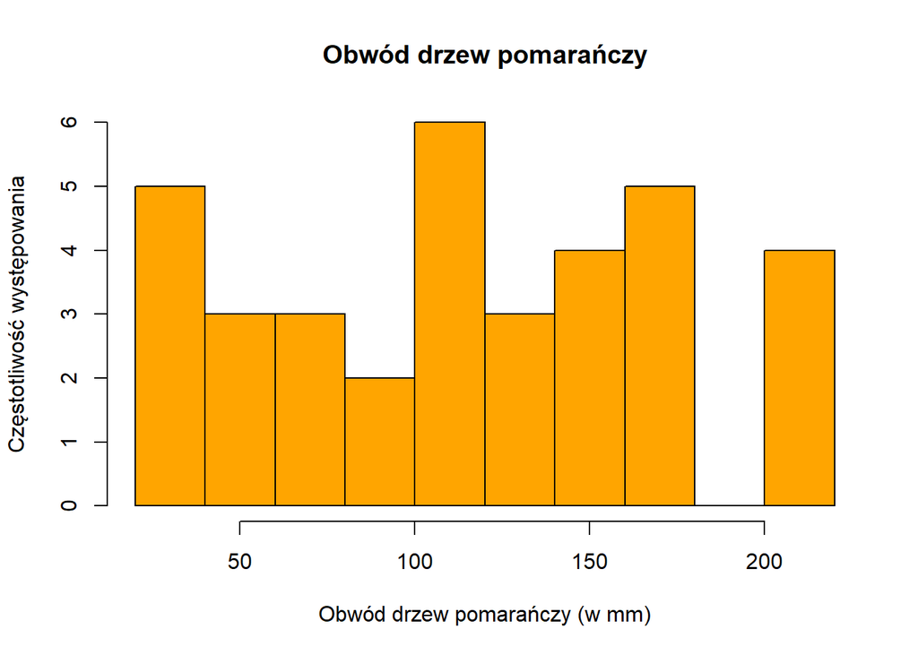

```r
obwód <- Orange$circumference
hist(obwód, col = 'orange', border = "black",
     xlab = "Obwód drzew pomarańczy (w mm)",
     ylab = "Częstotliwość występowania",
     main = 'Obwód drzew pomarańczy')
```

### Rysuję wykres pudełkowy z wąsem dla zmiennych: `mpg`, `hp` i `qsec` ze zbioru `mtcars`.

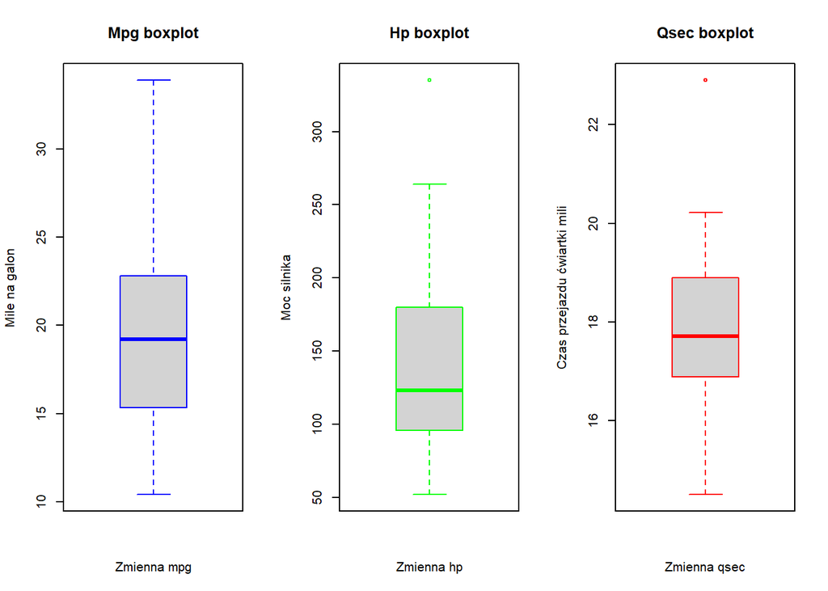

```r
# Tworzenie trzech wykresów pudełkowych obok siebie na jednym obrazie
# Dzielę obszar wykresu na 1 wiersz i 3 kolumny
# Parametr mfrow określa, ile wierszy i ile kolumn będzie w siatce wykresów

par(mfrow=c(1,3))

boxplot(mtcars$mpg,
        main = "Mpg boxplot",
        xlab = "Zmienna mpg" ,
        ylab ="Mile na galon",
        border = "blue",
        names = "mpg")

boxplot(mtcars$hp,
        main ="Hp boxplot",
        xlab = "Zmienna hp" ,
        ylab = "Moc silnika",
        border = "green",
        names = "hp")

boxplot(mtcars$qsec,
        main="Qsec boxplot",
        xlab = "Zmienna qsec" ,
        ylab = "Czas przejazdu ćwiartki mili",
        border = "red",
        names = "qsec")
```

```r
# Zresetowanie ustawień par i powrót do domyślego ustawienia

par(mfrow=c(1,1))
```

# Zadanie 5

### Instaluję i wczutuję pakiet `psych`.

```r
install.packages("psych", repos = "https://cran.rstudio.com/")
library(psych)
```

### Wczytuję dane z zestawu `mtcars` i korzystam z funkcji `describe()` i `summary()` do poznania statytysk opisowych dla danych `mtcars`.

```r
data("mtcars")
describe(mtcars)
```

|  | vars | n | mean | sd | median | trimmed | mad | min | max | range | skew | kurtosis | se |
| --- | --- | --- | --- | --- | --- | --- | --- | --- | --- | --- | --- | --- | --- |
| mpg | 1 | 32 | 20.090625 | 6.0269481 | 19.200 | 19.6961538 | 5.4114900 | 10.400 | 33.900 | 23.500 | 0.6106550 | -0.37276603 | 1.06542396 |
| cyl | 2 | 32 | 6.187500 | 1.7859216 | 6.000 | 6.2307692 | 2.9652000 | 4.000 | 8.000 | 4.000 | -0.1746119 | -1.76211977 | 0.31570933 |
| disp | 3 | 32 | 230.721875 | 123.9386938 | 196.300 | 222.5230769 | 140.4763500 | 71.100 | 472.000 | 400.900 | 0.3816570 | -1.20721195 | 21.90947271 |
| hp | 4 | 32 | 146.687500 | 68.5628685 | 123.000 | 141.1923077 | 77.0952000 | 52.000 | 335.000 | 283.000 | 0.7260237 | -0.13555112 | 12.12031731 |
| drat | 5 | 32 | 3.596563 | 0.5346787 | 3.695 | 3.5792308 | 0.7042350 | 2.760 | 4.930 | 2.170 | 0.2659039 | -0.71470062 | 0.09451874 |
| wt | 6 | 32 | 3.217250 | 0.9784574 | 3.325 | 3.1526923 | 0.7672455 | 1.513 | 5.424 | 3.911 | 0.4231465 | -0.02271075 | 0.17296847 |
| qsec | 7 | 32 | 17.848750 | 1.7869432 | 17.710 | 17.8276923 | 1.4158830 | 14.500 | 22.900 | 8.400 | 0.3690453 | 0.33511422 | 0.31588992 |
| vs | 8 | 32 | 0.437500 | 0.5040161 | 0.000 | 0.4230769 | 0.0000000 | 0.000 | 1.000 | 1.000 | 0.2402577 | -2.00193762 | 0.08909831 |
| am | 9 | 32 | 0.406250 | 0.4989909 | 0.000 | 0.3846154 | 0.0000000 | 0.000 | 1.000 | 1.000 | 0.3640159 | -1.92474143 | 0.08820997 |
| gear | 10 | 32 | 3.687500 | 0.7378041 | 4.000 | 3.6153846 | 1.4826000 | 3.000 | 5.000 | 2.000 | 0.5288545 | -1.06975068 | 0.13042656 |

[output cut: 1 more lines]

```r
summary(mtcars)
```

```
##       mpg             cyl             disp             hp
##  Min.   :10.40   Min.   :4.000   Min.   : 71.1   Min.   : 52.0
##  1st Qu.:15.43   1st Qu.:4.000   1st Qu.:120.8   1st Qu.: 96.5
##  Median :19.20   Median :6.000   Median :196.3   Median :123.0
##  Mean   :20.09   Mean   :6.188   Mean   :230.7   Mean   :146.7
##  3rd Qu.:22.80   3rd Qu.:8.000   3rd Qu.:326.0   3rd Qu.:180.0
##  Max.   :33.90   Max.   :8.000   Max.   :472.0   Max.   :335.0
##       drat             wt             qsec             vs
##  Min.   :2.760   Min.   :1.513   Min.   :14.50   Min.   :0.0000
##  1st Qu.:3.080   1st Qu.:2.581   1st Qu.:16.89   1st Qu.:0.0000
##  Median :3.695   Median :3.325   Median :17.71   Median :0.0000
##  Mean   :3.597   Mean   :3.217   Mean   :17.85   Mean   :0.4375
##  3rd Qu.:3.920   3rd Qu.:3.610   3rd Qu.:18.90   3rd Qu.:1.0000
##  Max.   :4.930   Max.   :5.424   Max.   :22.90   Max.   :1.0000
##        am              gear            carb
##  Min.   :0.0000   Min.   :3.000   Min.   :1.000
##  1st Qu.:0.0000   1st Qu.:3.000   1st Qu.:2.000
##  Median :0.0000   Median :4.000   Median :2.000
##  Mean   :0.4062   Mean   :3.688   Mean   :2.812
##  3rd Qu.:1.0000   3rd Qu.:4.000   3rd Qu.:4.000
##  Max.   :1.0000   Max.   :5.000   Max.   :8.000
```

- Funkcja `describe()` pokazała bardziej rozbudowane statystyki opisowe np. kurtozę dla każdej zmiennej z “mtcars”, podczas, gdy funkcja `summary()` dostarczyła bardziej podstawowy opis danych
- Funkcji `describeBy()` można użyć do uzyskania informacji o podstawowych statystykach, gdy zmienne są pogrupowane. Przydatne do tworzenia wykresów.
- Przykład zastosowania:  
  Dla zestawu danych zawierających informacje o uczniach i wynikach na egzaminie maturalnym. Dla zrozumienia różnic w wynikach między męzczyznami, a kobietami oraz województwami, z jakich pochodzą. Gdy podzielimy wyniki według województw i płci otrzymamy informacje statystyczne dla każdej kombinacji grupy, co pozwoli na analizę różnic w wynikach między tymi grupami.

# Zadanie 6

### Generuję 20 wyników rzutu kostką za pomocą funkcji `sample()`. Sprawdzam, ile wynosi średnia i odchylenie standardowe.

```r
proba <- sample(c(1:6), 20, replace = TRUE)
proba
```

```
##  [1] 2 3 4 6 1 4 2 1 1 3 1 1 6 6 5 1 2 6 5 1
```

```r
mean(proba)
```

```
## [1] 3.05
```

```r
sd(proba)
```

```
## [1] 2.012461
```

### Generuję 100 wyników rzutu monetą, a wyniki oznaczam: 0 - reszka, 1 - orzeł. Za pomocą funkcji `sum()` sprawdzam, ile wypadło orłów.

```r
rzut <- sample(c(0,1), 100, replace = TRUE)
rzut
```

```
##   [1] 1 1 1 0 1 1 0 1 0 1 0 1 1 1 1 1 0 0 1 0 0 1 1 0 1 1 1 1 1 1 1 0 0 1 0 1 0
##  [38] 1 1 0 1 0 0 1 1 0 0 1 0 0 0 1 0 1 1 1 0 0 1 0 0 1 1 0 0 0 0 0 1 0 1 1 0 0
##  [75] 1 1 1 1 1 0 1 1 1 0 0 1 0 0 0 0 1 0 1 0 0 1 0 1 1 1
```

```r
sum(rzut == TRUE)
```

```
## [1] 55
```

```r
los_nat <- sample(c(0:100, 10 , 1))
```

- `rnorm()` - generuje losowe liczby z rozkładu normalnego o określonych średniej i odchyleniu standardowym
- `rt()` - generuje losowe liczby z rozkłady t-Studenta o okreslonych stopniach swobody
- `srpois()` - generuje losowe liczby z przedziału Poissona o okreslonym paramentrze intensywności

### Dla dowolnego przykładu sprawdzam działanie funkcji `rnorm()` i wyświetlam początkowe obiekty w zbiorze.

```r
losowe_dane <- rnorm(100, mean = 0, sd = 1)
head(losowe_dane)
```

```
## [1]  0.6087500  0.9249278  1.5359806 -0.9452488 -0.4696740  0.5513439
```

# Zadanie 7

### Tworzę zestaw danych `lista` i go wyświetlam.

```r
lista <- list(palenie = c(F,T,T,F,F,T,F),
              cyfry = 0:9,
              macierz = matrix(sample(1:5,16,replace = T),4,4),
              tekst = c("Litwo", "ojczyzno", "moja", "ty",
                         "jestes", "jak", "zdrowie"))
print(lista)
```

```
## $palenie
## [1] FALSE  TRUE  TRUE FALSE FALSE  TRUE FALSE
##
## $cyfry
##  [1] 0 1 2 3 4 5 6 7 8 9
##
## $macierz
##      [,1] [,2] [,3] [,4]
## [1,]    2    3    5    1
## [2,]    1    3    4    4
## [3,]    3    4    2    1
## [4,]    5    1    1    5
##
## $tekst
## [1] "Litwo"    "ojczyzno" "moja"     "ty"       "jestes"   "jak"      "zdrowie"
```

### Odwołuję się do obiektów: `tekst`, 3 elementu wektora `cyfry` i 3 kolumny obiektu `macierz`.

```r
lista$tekst
```

```
## [1] "Litwo"    "ojczyzno" "moja"     "ty"       "jestes"   "jak"      "zdrowie"
```

```r
lista["tekst"]
```

```
## $tekst
## [1] "Litwo"    "ojczyzno" "moja"     "ty"       "jestes"   "jak"      "zdrowie"
```

```r
lista$cyfry[3]
```

```
## [1] 2
```

```r
lista$macierz[ ,3]
```

```
## [1] 5 4 2 1
```

```r
lista[["macierz"]][, 3]
```

```
## [1] 5 4 2 1
```

# Zadanie 8

### Definiuję zmienną `wiek` i `waga`.

```r
wiek <- c(50, 17, 39, 27, 90)
waga <- c(80, 75, 92, 105, 60)
```

### Na podstawie powyższych zmiennych buduję ramkę danych `pacjenci`.

```r
pacjenci <- data.frame(Wiek = wiek, Waga = waga)
pacjenci
```

| Wiek | Waga |
| --- | --- |
| 50 | 80 |
| 17 | 75 |
| 39 | 92 |
| 27 | 105 |
| 90 | 60 |

### Wykluczam z niej osoby o wadze > 90 kg lub osoby w wieku poniżej 18 lat.

```r
pacjenci_wykluczeni <- pacjenci[!(pacjenci$Waga > 90 | pacjenci$Wiek < 18), ]
pacjenci_wykluczeni
```

|  | Wiek | Waga |
| --- | --- | --- |
| 1 | 50 | 80 |
| 5 | 90 | 60 |

# Zadanie 9

### Instaluję i ładuję pakiet `nycflights13` i na jego podstawie buduje model regresji.

```r
install.packages("nycflights13", repos = "https://cran.rstudio.com/")
library(nycflights13)
flight_lm <- lm(arr_delay ~ dep_delay + month + carrier,
                data = flights)
```

### Szukam informacji ile elementów znajduje się W liście `nycflights13`.

```r
ilosc_elementow <- length(flight_lm)
cat(ilosc_elementow)
```

```
## 14
```

### Szukam informacji jak nazywają się elementy listy `nycflights13`.

```r
str(flight_lm)
```

```
## List of 14
##  $ coefficients : Named num [1:18] -9.517 1.019 0.022 1.007 -6.497 ...
##   ..- attr(*, "names")= chr [1:18] "(Intercept)" "dep_delay" "month" "carrierAA" ...
##  $ residuals    : Named num [1:327346] 17.8 24.7 39.5 -13.1 -11 ...
##   ..- attr(*, "names")= chr [1:327346] "1" "2" "3" "4" ...
##  $ effects      : Named num [1:327346] -3945.1 23360.9 24.6 -464.6 -273.1 ...
##   ..- attr(*, "names")= chr [1:327346] "(Intercept)" "dep_delay" "month" "carrierAA" ...
##  $ rank         : int 18
##  $ fitted.values: Named num [1:327346] -6.77 -4.73 -6.45 -4.9 -13.99 ...
##   ..- attr(*, "names")= chr [1:327346] "1" "2" "3" "4" ...
##  $ assign       : int [1:18] 0 1 2 3 3 3 3 3 3 3 ...
##  $ qr           :List of 5
##   ..$ qr   : num [1:327346, 1:18] -5.72e+02 1.75e-03 1.75e-03 1.75e-03 1.75e-03 ...
##   .. ..- attr(*, "dimnames")=List of 2
##   .. .. ..$ : chr [1:327346] "1" "2" "3" "4" ...
##   .. .. ..$ : chr [1:18] "(Intercept)" "dep_delay" "month" "carrierAA" ...
##   .. ..- attr(*, "assign")= int [1:18] 0 1 2 3 3 3 3 3 3 3 ...
##   .. ..- attr(*, "contrasts")=List of 1
##   .. .. ..$ carrier: chr "contr.treatment"
##   ..$ qraux: num [1:18] 1 1 1 1 1 ...
##   ..$ pivot: int [1:18] 1 2 3 4 5 6 7 8 9 10 ...
##   ..$ tol  : num 1e-07
##   ..$ rank : int 18
##   ..- attr(*, "class")= chr "qr"
##  $ df.residual  : int 327328
##  $ na.action    : 'omit' Named int [1:9430] 472 478 616 644 726 734 755 839 840 841 ...
##   ..- attr(*, "names")= chr [1:9430] "472" "478" "616" "644" ...
##  $ contrasts    :List of 1
##   ..$ carrier: chr "contr.treatment"
##  $ xlevels      :List of 1
##   ..$ carrier: chr [1:16] "9E" "AA" "AS" "B6" ...
##  $ call         : language lm(formula = arr_delay ~ dep_delay + month + carrier, data = flights)
##  $ terms        :Classes 'terms', 'formula'  language arr_delay ~ dep_delay + month + carrier
##   .. ..- attr(*, "variables")= language list(arr_delay, dep_delay, month, carrier)
##   .. ..- attr(*, "factors")= int [1:4, 1:3] 0 1 0 0 0 0 1 0 0 0 ...
##   .. .. ..- attr(*, "dimnames")=List of 2
##   .. .. .. ..$ : chr [1:4] "arr_delay" "dep_delay" "month" "carrier"
##   .. .. .. ..$ : chr [1:3] "dep_delay" "month" "carrier"
##   .. ..- attr(*, "term.labels")= chr [1:3] "dep_delay" "month" "carrier"
##   .. ..- attr(*, "order")= int [1:3] 1 1 1
```

[output cut: 13 more lines]

```
##   .. .. ..- attr(*, "factors")= int [1:4, 1:3] 0 1 0 0 0 0 1 0 0 0 ...
##   .. .. .. ..- attr(*, "dimnames")=List of 2
##   .. .. .. .. ..$ : chr [1:4] "arr_delay" "dep_delay" "month" "carrier"
##   .. .. .. .. ..$ : chr [1:3] "dep_delay" "month" "carrier"
##   .. .. ..- attr(*, "term.labels")= chr [1:3] "dep_delay" "month" "carrier"
##   .. .. ..- attr(*, "order")= int [1:3] 1 1 1
##   .. .. ..- attr(*, "intercept")= int 1
##   .. .. ..- attr(*, "response")= int 1
##   .. .. ..- attr(*, ".Environment")=<environment: R_GlobalEnv>
##   .. .. ..- attr(*, "predvars")= language list(arr_delay, dep_delay, month, carrier)
##   .. .. ..- attr(*, "dataClasses")= Named chr [1:4] "numeric" "numeric" "numeric" "character"
##   .. .. .. ..- attr(*, "names")= chr [1:4] "arr_delay" "dep_delay" "month" "carrier"
##   ..- attr(*, "na.action")= 'omit' Named int [1:9430] 472 478 616 644 726 734 755 839 840 841 ...
##   .. ..- attr(*, "names")= chr [1:9430] "472" "478" "616" "644" ...
##  - attr(*, "class")= chr "lm"
```

```r
nazwy_elementow <- names(flight_lm)
print(nazwy_elementow)
```

```
##  [1] "coefficients"  "residuals"     "effects"       "rank"
##  [5] "fitted.values" "assign"        "qr"            "df.residual"
##  [9] "na.action"     "contrasts"     "xlevels"       "call"
## [13] "terms"         "model"
```

### Wyświetlam informacje o współczynnikach tego modelu.

```r
coef(flight_lm)
```

```
## (Intercept)   dep_delay       month   carrierAA   carrierAS   carrierB6
## -9.51708354  1.01895142  0.02201799  1.00688211 -6.49669534  5.61792131
##   carrierDL   carrierEV   carrierF9   carrierFL   carrierHA   carrierMQ
##  1.61750225  4.95322249 10.70873197 10.54141321 -2.52973865  9.50579130
##   carrierOO   carrierUA   carrierUS   carrierVX   carrierWN   carrierYV
##  8.43129663  0.68573297  7.68631797 -1.86928468  1.02318926  5.66450384
```

# Zadanie 10

### Ładuję zestaw danych `VADeaths` i go wyświetlam.

```r
data("VADeaths")
str(VADeaths)
```

```
##  num [1:5, 1:4] 11.7 18.1 26.9 41 66 8.7 11.7 20.3 30.9 54.3 ...
##  - attr(*, "dimnames")=List of 2
##   ..$ : chr [1:5] "50-54" "55-59" "60-64" "65-69" ...
##   ..$ : chr [1:4] "Rural Male" "Rural Female" "Urban Male" "Urban Female"
```

```r
dimnames(VADeaths)
```

```
## [[1]]
## [1] "50-54" "55-59" "60-64" "65-69" "70-74"
##
## [[2]]
## [1] "Rural Male"   "Rural Female" "Urban Male"   "Urban Female"
```

Macierz VADeaths przedstawia dane dotyczące liczby zgonów według wieku (reprezentowane przez nazwy wierszy) i płci (nazwy kolumn).

### Dzielę macierz na dwie podmacierze.

```r
VADeaths_mezczyzni <- VADeaths[ , c("Rural Male", "Urban Male")]
VADeaths_mezczyzni
```

```
##       Rural Male Urban Male
## 50-54       11.7       15.4
## 55-59       18.1       24.3
## 60-64       26.9       37.0
## 65-69       41.0       54.6
## 70-74       66.0       71.1
```

```r
VADeaths_kobiety <- VADeaths[ , c("Rural Female", "Urban Female")]
VADeaths_kobiety
```

```
##       Rural Female Urban Female
## 50-54          8.7          8.4
## 55-59         11.7         13.6
## 60-64         20.3         19.3
## 65-69         30.9         35.1
## 70-74         54.3         50.0
```

### Obliczam średnie dla każdej kolumny z macierzy, korzystając z funkcji `colMeans()` i dodaje je do macierzy poprzez funkcję`rbind()`.

```r
srednie_kolumn <- colMeans(VADeaths)
rbind(VADeaths, srednie_kolumn)
```

```
##                Rural Male Rural Female Urban Male Urban Female
## 50-54               11.70         8.70      15.40         8.40
## 55-59               18.10        11.70      24.30        13.60
## 60-64               26.90        20.30      37.00        19.30
## 65-69               41.00        30.90      54.60        35.10
## 70-74               66.00        54.30      71.10        50.00
## srednie_kolumn      32.74        25.18      40.48        25.28
```

### Obliczam średnie dla każdego wiersza z macierzy, korzystając z funkcji `rowMeans()` i dodaje je do macierzy poprzez funkcję`cbind()`.

```r
srednie_wierszy <- rowMeans(VADeaths)
cbind(VADeaths, srednie_wierszy)
```

```
##       Rural Male Rural Female Urban Male Urban Female srednie_wierszy
## 50-54       11.7          8.7       15.4          8.4          11.050
## 55-59       18.1         11.7       24.3         13.6          16.925
## 60-64       26.9         20.3       37.0         19.3          25.875
## 65-69       41.0         30.9       54.6         35.1          40.400
## 70-74       66.0         54.3       71.1         50.0          60.350
```

# Zadanie 11

### Tworzę zmienną `czy_podzielna`. Używam instrukcji `if-else` oraz funkcji `ifelse()` do sprawdzenia, czy dowolna liczba jest podzielna przez 4.

```r
czy_podzielna <- 40
if (czy_podzielna %% 4 == 0){
  cat(czy_podzielna, "jest podzielna przez 4\n")
} else {
  cat(czy_podzielna, "nie jest podzielna przez 4\n")
}
```

```
## 40 jest podzielna przez 4
```

### Tworzę zmienne pomocnicze `inna_czy_podzielna` oraz `wynik` do zobrazowania działania funkcji.

```r
inna_czy_podzielna <- 7
wynik <- ifelse(inna_czy_podzielna %% 4 == 0, "Tak", "Nie")
cat("Czy", inna_czy_podzielna, "jest podzielna przez 4? \n" , wynik)
```

```
## Czy 7 jest podzielna przez 4?
##  Nie
```

# Zadanie 12

### Tworzę zmienną `ksiazki` .

```r
ksiazki <- sample(0:4, size = 25, replace = TRUE)
ksiazki
```

```
##  [1] 1 2 3 1 0 0 4 4 3 2 4 4 0 0 2 1 3 0 4 1 1 4 2 4 4
```

### Na jej podstawie badam, ile wynosi średnia przeczytanych książek.

```r
mean(ksiazki)
```

```
## [1] 2.16
```

### Na jej podstawie badam, ile osób przeczytało przynajmniej 3 książki.

```r
liczba_osob_czytajaca_min_trzy <- sum(ksiazki >= 3)
liczba_osob_czytajaca_min_trzy
```

```
## [1] 11
```

### Na jej podstawie badam, ile osób nie przeczytało żadnej książki.

```r
liczba_osob_nie_czyt <- sum (ksiazki == 0)
liczba_osob_nie_czyt
```

```
## [1] 5
```

### Tworzę zmienną `ksiazki2`, która przechowuje informację, czy ktoś czyta książki.

```r
# Tworzenie wektora wypełnionego zerami, do przechowywania informacji o czytaniu ksiązek.

ksiazki2 <- rep(0, length(ksiazki))
ksiazki2
```

```
##  [1] 0 0 0 0 0 0 0 0 0 0 0 0 0 0 0 0 0 0 0 0 0 0 0 0 0
```

```r
# Sprawdzanie, które z osób przeczytała min. 1 książkę i oznaczenie ich jako "1" w wektorze ksiazki2

for(i in 1:length(ksiazki)){
  if(ksiazki[i] > 0){
    ksiazki2[i] <- 1
  }
}

ksiazki2
```

```
##  [1] 1 1 1 1 0 0 1 1 1 1 1 1 0 0 1 1 1 0 1 1 1 1 1 1 1
```

### Tworzę instrukcję warunkową, która mając datę (miesiąc i rok), odpowie na pytanie o liczbę dni w tym miesiącu.

```r
# Przykładowy miesiąc i rok
miesiac <- 11
rok <- 2003

# Sprawdzanie, czy miesiąc to lity, a następnie, czy rok jest przestępny
if (miesiac == 2) {
  if ((rok %% 4 == 0 && rok %% 100 != 0) || rok %% 400 == 0) {
    liczba_dni <- 29
  } else {
    liczba_dni <- 28
  }
} else if (miesiac %in% c(4, 6, 9, 11)) {
  liczba_dni <- 30
} else {
  liczba_dni <- 31
}

cat("Liczba dni w podanym miesiącu i roku:", liczba_dni, "\n")
```

```
## Liczba dni w podanym miesiącu i roku: 30
```

# Zadanie 13

```r
konwersja_temperatury <- function(temperatura_C) {
  temperatura_K <- temperatura_C + 273.15  # Konwersja na Kelwiny
  temperatura_F <- (temperatura_C * 9/5) + 32  # Konwersja na Fahrenheity

  wynik <- data.frame(Celsjusze = temperatura_C, Kelwiny = temperatura_K, Fahrenheity = temperatura_F)
  return(wynik)
}
```

### Wywołuję funkcję, dla przykładowej wartości temperatury równej 30 stopni Celsjusza i wyświetlam wynik.

```r
wynik_konwersji <- konwersja_temperatury(30)
wynik_konwersji
```

| Celsjusze | Kelwiny | Fahrenheity |
| --- | --- | --- |
| 30 | 303.15 | 86 |

# Zadanie 14

### Tworzę funkcję `pole_trojkata()`, która na podstawie długości boków trójkąta, wyznacza jego pole.

Funkcja wyświetli komunikat, jeśli podane długości boków nie stworzą trójkąta.

```r
pole_trojkata <- function(a, b, c) {

  # Sprawdzenie, czy podane długości boków mogą utworzyć trójkąt
  if (a + b > c && a + c > b && b + c > a) {

    # Obliczenie s, czyli połowy długości obwodu
    s <- (a + b + c) / 2

    # Obliczenie pola trójkąta za pomocą wzoru Herona
    pole <- sqrt(s * (s - a) * (s - b) * (s - c))
    return(pole)

  } else {
    # Wyświetlenie komunikatu, gdy podane długości boków nie stworzą trójkąta
    cat("Podane długości boków nie tworzą trójkąta.\n")
    return(NULL)
  }
}
```

### Dla odcinków o długości: (6, 8, 10) oraz (1, 2, 3) sprawdzam działanie funkcji

```r
pole1 <- pole_trojkata(6, 8, 10)
cat("Pole trójkąta wynosi:", pole1, "\n")
```

```
## Pole trójkąta wynosi: 24
```

```r
pole2 <- pole_trojkata(1, 2, 3)
```

```
## Podane długości boków nie tworzą trójkąta.
```

# Zadanie 15

### Tworzę funkcję `typ_trojkata()`, która na podstawie sum kwadratów długości boków trójkąta, określi typ trójkąta.

Funkcja wyświetli komunikat, jeśli podane długości boków nie stworzą trójkąta.

```r
typ_trojkata <- function(a, b, c) {
  # Sprawdzenie, czy podane długości boków mogą utworzyć trójkąt
  if (a + b > c && a + c > b && b + c > a) {
    # Obliczenie kwadratów długości boków i przypisanie ich do zmiennych
    a2 <- a^2
    b2 <- b^2
    c2 <- c^2

    # Sprawdzenie, czy trójkąt jest ostrokątny
    if (a2 + b2 > c2 && a2 + c2 > b2 && b2 + c2 > a2) {
      return("Ostrokątny")
    }

    # Sprawdzenie, czy trójkąt jest prostokątny
    else if (a2 + b2 == c2 || a2 + c2 == b2 || b2 + c2 == a2) {
      return("Prostokątny")
    }

    # W przeciwnym razie, trójkąt jest rozwartokątny
    else {
      return("Rozwartokątny")
    }
  } else {
    # Wyświetlenie komunikatu, gdy podane długości boków nie stworzą trójkąta
    cat("Podane długości boków nie tworzą trójkąta.\n")
    return(NULL)
  }
}
```

### Test użycia funkcji dla długości boków: (6, 8, 10) i (1, 2, 3).

```r
typ1 <- typ_trojkata(6, 8, 10)
cat("Trójkąt jest:", typ1, "\n")
```

```
## Trójkąt jest: Prostokątny
```

```r
typ2 <- typ_trojkata(1, 2, 3)
```

```
## Podane długości boków nie tworzą trójkąta.
```

# Zadanie 16

### Tworzę ramkę danych `osoby`.

```r
wzrost <- round(rnorm(100, 175, 10),0)
waga   <- round(wzrost - 105 + rnorm(1,0,5))
wiek   <- sample(20:60, 100, replace = TRUE)
dzieci <- rpois(100, lambda = 1)
osoby  <- data.frame(wzrost = wzrost, waga = waga,
                     wiek = wiek, dzieci = dzieci)

osoby
```

| wzrost | waga | wiek | dzieci |
| --- | --- | --- | --- |
| 178 | 72 | 56 | 2 |
| 187 | 81 | 38 | 4 |
| 176 | 70 | 26 | 1 |
| 180 | 74 | 36 | 2 |
| 164 | 58 | 38 | 1 |
| 170 | 64 | 37 | 2 |
| 172 | 66 | 47 | 1 |
| 191 | 85 | 47 | 1 |
| 185 | 79 | 23 | 0 |
| 186 | 80 | 57 | 0 |

[output cut: 90 more lines]

### Dołączam do zestawu zmienną `BMI` oraz zmienną `plec`.

```r
osoby$BMI <- osoby$waga / ((osoby$wzrost / 100) ^ 2)
str(osoby)
```

```
## 'data.frame':    100 obs. of  5 variables:
##  $ wzrost: num  178 187 176 180 164 170 172 191 185 186 ...
##  $ waga  : num  72 81 70 74 58 64 66 85 79 80 ...
##  $ wiek  : int  56 38 26 36 38 37 47 47 23 57 ...
##  $ dzieci: int  2 4 1 2 1 2 1 1 0 0 ...
##  $ BMI   : num  22.7 23.2 22.6 22.8 21.6 ...
```

```r
osoby$plec <- rep(c("Kobieta", "Mężczyzna"), each = 50)
osoby
```

| wzrost | waga | wiek | dzieci | BMI | plec |
| --- | --- | --- | --- | --- | --- |
| 178 | 72 | 56 | 2 | 22.72440 | Kobieta |
| 187 | 81 | 38 | 4 | 23.16337 | Kobieta |
| 176 | 70 | 26 | 1 | 22.59814 | Kobieta |
| 180 | 74 | 36 | 2 | 22.83951 | Kobieta |
| 164 | 58 | 38 | 1 | 21.56454 | Kobieta |
| 170 | 64 | 37 | 2 | 22.14533 | Kobieta |
| 172 | 66 | 47 | 1 | 22.30936 | Kobieta |
| 191 | 85 | 47 | 1 | 23.29980 | Kobieta |
| 185 | 79 | 23 | 0 | 23.08254 | Kobieta |
| 186 | 80 | 57 | 0 | 23.12406 | Kobieta |

[output cut: 90 more lines]

### Wyświetlam pierwsze i ostatnie wiersze z zestawu danych.

```r
head(osoby)
```

|  | wzrost | waga | wiek | dzieci | BMI | plec |
| --- | --- | --- | --- | --- | --- | --- |
| 1 | 178 | 72 | 56 | 2 | 22.72440 | Kobieta |
| 2 | 187 | 81 | 38 | 4 | 23.16337 | Kobieta |
| 3 | 176 | 70 | 26 | 1 | 22.59814 | Kobieta |
| 4 | 180 | 74 | 36 | 2 | 22.83951 | Kobieta |
| 5 | 164 | 58 | 38 | 1 | 21.56454 | Kobieta |
| 6 | 170 | 64 | 37 | 2 | 22.14533 | Kobieta |

```r
tail(osoby)
```

|  | wzrost | waga | wiek | dzieci | BMI | plec |
| --- | --- | --- | --- | --- | --- | --- |
| 95 | 166 | 60 | 24 | 0 | 21.77384 | Mężczyzna |
| 96 | 176 | 70 | 34 | 1 | 22.59814 | Mężczyzna |
| 97 | 173 | 67 | 57 | 1 | 22.38631 | Mężczyzna |
| 98 | 183 | 77 | 46 | 0 | 22.99262 | Mężczyzna |
| 99 | 174 | 68 | 31 | 0 | 22.46003 | Mężczyzna |
| 100 | 178 | 72 | 36 | 2 | 22.72440 | Mężczyzna |

### Wyświetlam informacje o strukturze, wielkości i podstawowych statystykach zestawu danych.

```r
str(osoby)
```

```
## 'data.frame':    100 obs. of  6 variables:
##  $ wzrost: num  178 187 176 180 164 170 172 191 185 186 ...
##  $ waga  : num  72 81 70 74 58 64 66 85 79 80 ...
##  $ wiek  : int  56 38 26 36 38 37 47 47 23 57 ...
##  $ dzieci: int  2 4 1 2 1 2 1 1 0 0 ...
##  $ BMI   : num  22.7 23.2 22.6 22.8 21.6 ...
##  $ plec  : chr  "Kobieta" "Kobieta" "Kobieta" "Kobieta" ...
```

```r
dim(osoby)
```

```
## [1] 100   6
```

```r
summary(osoby)
```

```
##      wzrost           waga            wiek           dzieci          BMI
##  Min.   :145.0   Min.   :39.00   Min.   :20.00   Min.   :0.00   Min.   :18.55
##  1st Qu.:169.0   1st Qu.:63.00   1st Qu.:34.00   1st Qu.:0.00   1st Qu.:22.06
##  Median :174.0   Median :68.00   Median :43.50   Median :1.00   Median :22.46
##  Mean   :174.2   Mean   :68.16   Mean   :42.02   Mean   :1.07   Mean   :22.33
##  3rd Qu.:179.0   3rd Qu.:73.00   3rd Qu.:52.00   3rd Qu.:2.00   3rd Qu.:22.78
##  Max.   :198.0   Max.   :92.00   Max.   :60.00   Max.   :5.00   Max.   :23.47
##      plec
##  Length:100
##  Class :character
##  Mode  :character
##
##
##
```

### Sprawdzam, ile osób posiada min. 2 dzieci.

```r
z_min_dwojka_dzieci <- sum(osoby$dzieci >= 2)
z_min_dwojka_dzieci
```

```
## [1] 28
```

### Wyświetlam osoby o wzroście min. 185 cm.

```r
osoby_z_185 <- osoby[osoby$wzrost >= 185, ]
osoby_z_185
```

|  | wzrost | waga | wiek | dzieci | BMI | plec |
| --- | --- | --- | --- | --- | --- | --- |
| 2 | 187 | 81 | 38 | 4 | 23.16337 | Kobieta |
| 8 | 191 | 85 | 47 | 1 | 23.29980 | Kobieta |
| 9 | 185 | 79 | 23 | 0 | 23.08254 | Kobieta |
| 10 | 186 | 80 | 57 | 0 | 23.12406 | Kobieta |
| 34 | 190 | 84 | 35 | 0 | 23.26870 | Kobieta |
| 40 | 191 | 85 | 41 | 5 | 23.29980 | Kobieta |
| 48 | 187 | 81 | 49 | 2 | 23.16337 | Kobieta |
| 51 | 193 | 87 | 43 | 3 | 23.35633 | Mężczyzna |
| 61 | 186 | 80 | 27 | 0 | 23.12406 | Mężczyzna |
| 69 | 191 | 85 | 47 | 0 | 23.29980 | Mężczyzna |

[output cut: 3 more lines]

### Obliczam średni wzrost w badanej grupie.

```r
średni_wzrost <- mean(osoby$wzrost)
średni_wzrost
```

```
## [1] 174.16
```

### Sprawdzam, kto przeciętnie jest wyższy: kobiety, czy mężczyźni.

```r
library(psych)
```

```r
statystyki_osoby <- describeBy(osoby$wzrost, osoby$plec)
print(statystyki_osoby)
```

```
##
##  Descriptive statistics by group
## group: Kobieta
##    vars  n   mean   sd median trimmed  mad min max range skew kurtosis   se
## X1    1 50 174.78 7.88  174.5  174.55 6.67 157 191    34 0.18    -0.49 1.11
## ------------------------------------------------------------
## group: Mężczyzna
##    vars  n   mean    sd median trimmed  mad min max range  skew kurtosis  se
## X1    1 50 173.54 10.63    174  173.93 8.15 145 198    53 -0.36     0.29 1.5
```

```r
średnia_kobiet <- statystyki_osoby$Kobieta$mean
średnia_kobiet
```

```
## [1] 174.78
```

```r
średnia_mezczyzn <- statystyki_osoby$Mężczyzna$mean
średnia_mezczyzn
```

```
## [1] 173.54
```

### Po przeanalizowaniu wyników tworzę nierówność, na podstawie której będzie możliwa ocena kto jest przeciętnie wyższy: kobiety, czy mężczyżni.

```r
średnia_kobiet > średnia_mezczyzn
```

```
## [1] TRUE
```

### Pokazuje osoby o BMI wyższym niż 30.

```r
osoby_BMI <- osoby[osoby$BMI > 30, ]
sum(osoby_BMI)
```

```
## [1] 0
```

```r
ilosc_mezczyzn <- sum(osoby_BMI$plec == "Mężczyzna")
ilosc_kobiet <- sum(osoby_BMI$plec == "Kobieta")
```

Dla tego zestawu danych, nie ma osób o BMI wyższym niż 30.

### Dodaję do zestawu zmienną `wzrost2`.

```r
wzrost2 <- osoby$wzrost
wzrost2[wzrost2 > 185] <- "wysoki"
wzrost2[wzrost2 < 165] <- "niski"
wzrost2[(wzrost2 <= 185) & (wzrost2 >= 165)] <- "sredni"
wzrost2
```

```
##   [1] "sredni" "wysoki" "sredni" "sredni" "niski"  "sredni" "sredni" "wysoki"
##   [9] "sredni" "wysoki" "sredni" "sredni" "sredni" "sredni" "sredni" "sredni"
##  [17] "sredni" "sredni" "sredni" "sredni" "sredni" "niski"  "sredni" "sredni"
##  [25] "sredni" "sredni" "sredni" "niski"  "sredni" "sredni" "niski"  "sredni"
##  [33] "niski"  "wysoki" "sredni" "sredni" "sredni" "sredni" "sredni" "wysoki"
##  [41] "sredni" "sredni" "sredni" "sredni" "sredni" "sredni" "sredni" "wysoki"
##  [49] "niski"  "sredni" "wysoki" "sredni" "sredni" "sredni" "sredni" "sredni"
##  [57] "sredni" "niski"  "niski"  "niski"  "wysoki" "sredni" "sredni" "sredni"
##  [65] "sredni" "sredni" "sredni" "sredni" "wysoki" "wysoki" "sredni" "sredni"
##  [73] "sredni" "niski"  "sredni" "sredni" "sredni" "niski"  "sredni" "sredni"
##  [81] "niski"  "sredni" "sredni" "sredni" "sredni" "wysoki" "niski"  "niski"
##  [89] "sredni" "sredni" "wysoki" "niski"  "sredni" "niski"  "sredni" "sredni"
##  [97] "sredni" "sredni" "sredni" "sredni"
```

### Korzystan z funkcji `summary()`

```r
summary(wzrost2)
```

```
##    Length     Class      Mode
##       100 character character
```

Dla tak przedstawionych danych, nie mogę określić, ile osób wysokich, dlatego zmieniam typ tej zmiennej na `factor`.

### Zmieniam typ zmiennej `wzrost2` na typ `factor`.

```r
wzrost2 <- as.factor(wzrost2)
wzrost2
```

```
##   [1] sredni wysoki sredni sredni niski  sredni sredni wysoki sredni wysoki
##  [11] sredni sredni sredni sredni sredni sredni sredni sredni sredni sredni
##  [21] sredni niski  sredni sredni sredni sredni sredni niski  sredni sredni
##  [31] niski  sredni niski  wysoki sredni sredni sredni sredni sredni wysoki
##  [41] sredni sredni sredni sredni sredni sredni sredni wysoki niski  sredni
##  [51] wysoki sredni sredni sredni sredni sredni sredni niski  niski  niski
##  [61] wysoki sredni sredni sredni sredni sredni sredni sredni wysoki wysoki
##  [71] sredni sredni sredni niski  sredni sredni sredni niski  sredni sredni
##  [81] niski  sredni sredni sredni sredni wysoki niski  niski  sredni sredni
##  [91] wysoki niski  sredni niski  sredni sredni sredni sredni sredni sredni
## Levels: niski sredni wysoki
```

```r
summary(wzrost2)
```

```
##  niski sredni wysoki
##     16     72     12
```

Po dokonanej zmianie funckja `summary()` zwróciła informację o liczbie osób niskich, średnich oraz wysokich.

# Zadanie 17

### Tworzę zestaw danych `lista_17`.

```r
lista_17 <- list(palenie = c(F,T,T,F,F,T,F),
              cyfry = 0:9,
              macierz = matrix(sample(1:5, 16, replace = T), 4, 4),
              tekst <- c("Litwo", "ojczyzno", "moja", "ty",
                         "jestes", "jak", "zdrowie"))
```

### Odwołuję się do obiektu `tekst`.

```r
lista$tekst
```

```
## [1] "Litwo"    "ojczyzno" "moja"     "ty"       "jestes"   "jak"      "zdrowie"
```

```r
lista["tekst"]
```

```
## $tekst
## [1] "Litwo"    "ojczyzno" "moja"     "ty"       "jestes"   "jak"      "zdrowie"
```

### Odwołuję się do trzeciego elementu wektora `cyfry`.

```r
lista$cyfry[3]
```

```
## [1] 2
```

### Odwołuję się do trzeciej kolumny obiektu `macierz`.

```r
lista$macierz[, 3]
```

```
## [1] 5 4 2 1
```

```r
lista[["macierz"]][, 3]
```

```
## [1] 5 4 2 1
```

### Używam instrukcji `if-else` oraz funkcji `ifelse()` do sprawdzenia, czy dowolna liczba jest podzielna przez 5.

```r
czy_podzielna_b <- 15
if (czy_podzielna_b %% 5 == 0){
  cat(czy_podzielna_b, "jest podzielna przez 5\n")
} else {
  cat(czy_podzielna_5, "nie jest podzielna przez 5\n")
}
```

```
## 15 jest podzielna przez 5
```

### Tworzę zmienne pomocnicze `czy_podzielna`, `inna_czy_podzielna` oraz `wynik` do zoobrazowania działania funkcji.

```r
inna_czy_podzielna_b <- 10
wynik_b <- ifelse(inna_czy_podzielna_b %% 5 == 0, "Tak", "Nie")
cat("Czy" , inna_czy_podzielna_b, "jest podzielna przez 5? \n" , wynik_b)
```

```
## Czy 10 jest podzielna przez 5?
##  Tak
```

# Zadanie 18

### Tworzę zmienną `ksiazki` mowiącą o tym, ile dana osoba przeczytała książek w ostatnim kwartale.

```r
ksiazki_1 <- sample(0:4, size = 25, replace = TRUE)
```

### Badam, ile wynosi średnia liczba przeczytanych książek.

```r
średnia_ksiazek <- mean(ksiazki_1)
zaokrąglona_srednia <- round(średnia_ksiazek, 0)
zaokrąglona_srednia
```

```
## [1] 2
```

### Badam, ile osób przeczytało przynajmniej 3 książki.

```r
liczba_osob_czytajaca_min_trzy <- sum(ksiazki_1 >= 3)
liczba_osob_czytajaca_min_trzy
```

```
## [1] 10
```

### Badam, ile osó nie przeczytało żadnej książki.

```r
liczba_osob_nie_czyt <- sum (ksiazki_1 == 0)
liczba_osob_nie_czyt
```

```
## [1] 6
```

### Tworzę zmienną `ksiazki_2`, która będzie mówiła, czy ktoś przeczytał minimum 1 książkę.

```r
# Tworzenie wektora wypełnionego zerami, do przechowywania informacji o czytaniu ksiązek.

ksiazki_2 <- rep(0, length(ksiazki_1))
ksiazki_2
```

```
##  [1] 0 0 0 0 0 0 0 0 0 0 0 0 0 0 0 0 0 0 0 0 0 0 0 0 0
```

```r
# Sprawdzanie, które z osób przeczytała min. 1 książkę i oznaczenie ich jako "1" w wektorze ksiazki_2

for(i in 1:length(ksiazki_1)){
  if(ksiazki_1[i] > 0){
    ksiazki_2[i] <- 1
  }
}

ksiazki_2
```

```
##  [1] 1 1 1 1 1 0 0 1 1 1 1 1 1 1 0 0 0 1 1 1 1 1 1 0 1
```

# Zadanie 19

### Tworzę funkcję, która mając datą (miesiąc i rok) odpowie na pytanie o liczbę dni w tym miesiącu.

```r
liczba_dni_w_miesiacu <- function(miesiace, lata) {
  if (miesiace == 2) {
    if ((lata %% 4 == 0 && lata %% 100 != 0) || lata %% 400 == 0) {
      ile_dni <- 29
      cat("Liczba dni w podanym miesiącu i roku:", ile_dni, "\n")
    } else {
      ile_dni <- 28
      cat("Liczba dni w podanym miesiącu i roku:", ile_dni, "\n")
    }
  } else if (miesiace %in% c(4, 6, 9, 11)) {
    ile_dni <- 30
    cat("Liczba dni w podanym miesiącu i roku:", ile_dni, "\n")
  } else {
    ile_dni <- 31
    cat("Liczba dni w podanym miesiącu i roku:", ile_dni, "\n")
  }
}
```

### Testuję działanie funkcji dla lutego 2004 roku.

```r
liczba_dni_w_miesiacu(2, 2004)
```

```
## Liczba dni w podanym miesiącu i roku: 29
```

# Zadanie 20

Liczby wesołe to liczby naturalne, które w wyniku podzielenia tej liczby na jej cyfr, podniesieniu każdej jej cyfry do kwadratu i dodaniu wyników kwadratów cyfr, kończą się cyklem wynikającym w wartości 1 lub 4, przy czym liczby kończące się cyklem 1 uważane są za wesołe.

```r
czy_wesola <- function(n) {

  # Pusty wektor do śledzenia historii wartości
  historia <- c()

  while (n != 1 && !n %in% historia) {
    historia <- c(historia, n)
    cyfry <- as.integer(unlist(strsplit(as.character(n), "")))
    cykl <- sum(cyfry^2)
  }

  return(cykl == 1)
}
```

**Objaśnienie użytych funkcji:**

- `as.character(n)`: Funkcja *as.character()* konwertuje liczbę n na łańcuch znaków.
- `strsplit(as.character(n), "")`: Funkcja *strsplit()* dzieli ciąg znaków na elementy. W tym przypadku dzielona jest liczba n, a jako separator podawany jest pusty ciąg ““. Dzięki temu liczba zostaje podzielona na pojedyncze znaki i zapisana jako lista znaków.
- `unlist()`: Funkcja *unlist()* konwertuje listę na zwykły wektor, usuwając zagnieżdżenie.
- `as.integer()`: Funkcja *as.integer()* konwertuje każdy znak w wektorze na liczbę całkowitą. W wyniku otrzymujemy wektor liczb całkowitych, reprezentujący poszczególne cyfry liczby n.

### Dla liczb: 19 i 4 testuję działanie funkcji.

```r
liczba1 <- 19
liczba2 <- 4

if (czy_wesola(liczba1)) {
  cat(liczba1, "jest liczbą wesołą.\n")
} else {
  cat(liczba1, "nie jest liczbą wesołą.\n")
}
```

[output not shown]

```r
if (czy_wesola(liczba2)) {
  cat(liczba2, "jest liczbą wesołą.\n")
} else {
  cat(liczba2, "nie jest liczbą wesołą.\n")
}
```

```
## 4 nie jest liczbą wesołą.
```